# MLE ane MM Deliverable MLE Part(Glycohemoglobin)

Dong Chen

10-26

# 1 Introduction

Maximum likelihood (MLE) and method of moments (MM) are two common methods for constructing a model.

# 2 Background

I will explain to the reader how one might use MLE and MM to model (a) Glycohemoglobin and (b) Height of adult females. The data will be from National Health and Nutrition Examination Survey 2009-2010 (NHANES), available from the Hmisc package. I will compare and contrast the two methods in addition to comparing and contrasting the choice of underlying distribution.

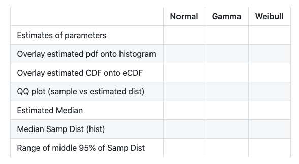

# 3 Method

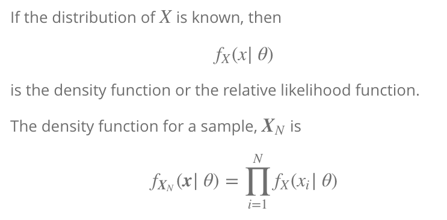

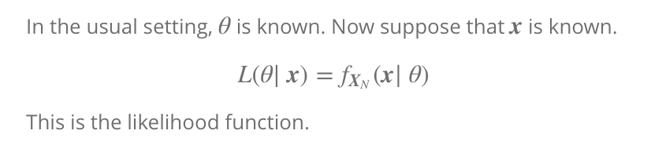

## 3.1 Data

```r
#Import data
require(dplyr)
Hmisc::getHdata(nhgh)
d1 <- nhgh %>%
  filter(sex == "female") %>%
  filter(age >= 18) %>%
  select(gh, ht) %>%
  filter(1:n()<=1000)
```

## 3.2 Normal Distribution

### 3.2.1 Estimates of parameters

```r
#HT,Normal, MLE
ll <- function(params, data)  sum(dnorm(data,params[1],params[2],log=TRUE))
#ll(c(2,3),d1$gh)
g <- function(x) {
  out <- x
  for(i in seq_along(x)){
    out[i] <- ll(c(x[i],1),d1$gh)
  }
  out
}

h <- function(x) {
  out <- x
  for(i in seq_along(x)){
    out[i] <- ll(c(5.7,x[i]),d1$gh)
  }
  out
}
```

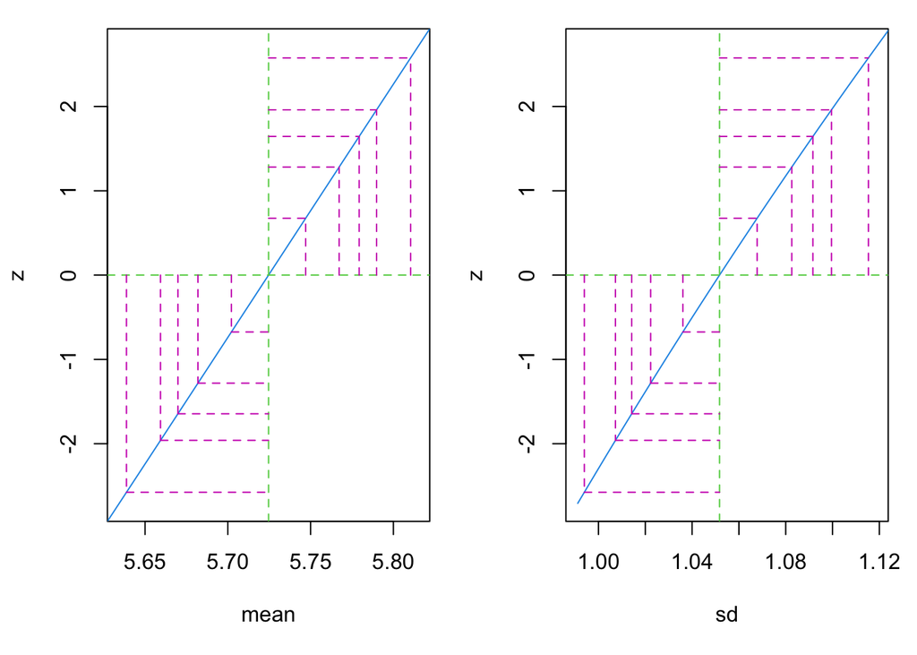

```r
require(stats4)
nLL <- function(mean, sd){
  fs <- dnorm(
        x = d1$gh
      , mean = mean
      , sd = sd
      , log = TRUE
    )
  -sum(fs)
}
param_hat <- mle(
    nLL
  , start = list(mean = 5.7, sd = 1)
  , method = "L-BFGS-B"
  , lower = c(0, 0.01)
)

par(mfrow = c(1,2)); plot(profile(param_hat), absVal = FALSE)
```

In this chunk, we use function to calculate the MLE when set two parameters that close to real MLE. From the figure, we can see when z=0, the two parameters are what we need.

```r
coef(param_hat)
```

```
##     mean       sd
## 5.724600 1.051721
```

This is the specific value of the two parameters.

### 3.2.2 Overlay estimated pdf onto histogram

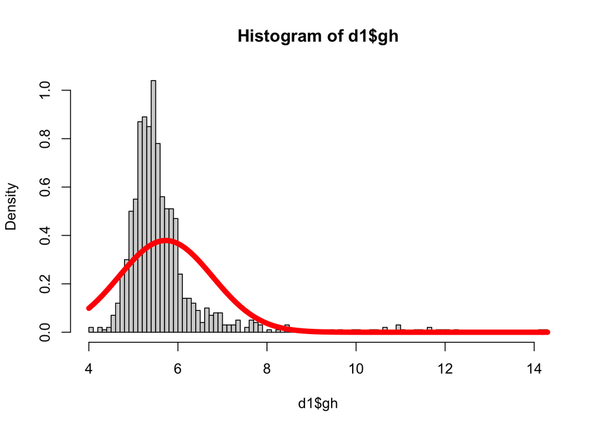

```r
hist(d1$gh,breaks = 100, freq = FALSE)
curve(dnorm(x,mean=coef(param_hat)[1],sd=coef(param_hat)[2]),col="red",lwd=6,add=T)
```

The figure above is that overlay estimated pdf onto histogram of the empirical distribution. It can be seen that their distribution is very concentrated in the 4-8 interval.

### 3.2.3 Overlay estimated CDF onto eCDF

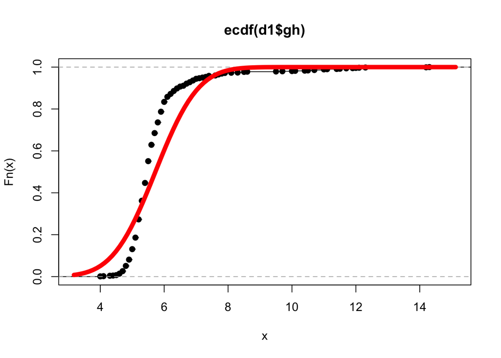

```r
plot(ecdf(d1$gh))
curve(pnorm(x,mean=coef(param_hat)[1],sd=coef(param_hat)[2]),col="red",lwd=6,add=T)
```

### 3.2.4 QQ plot (sample vs estimated dist)

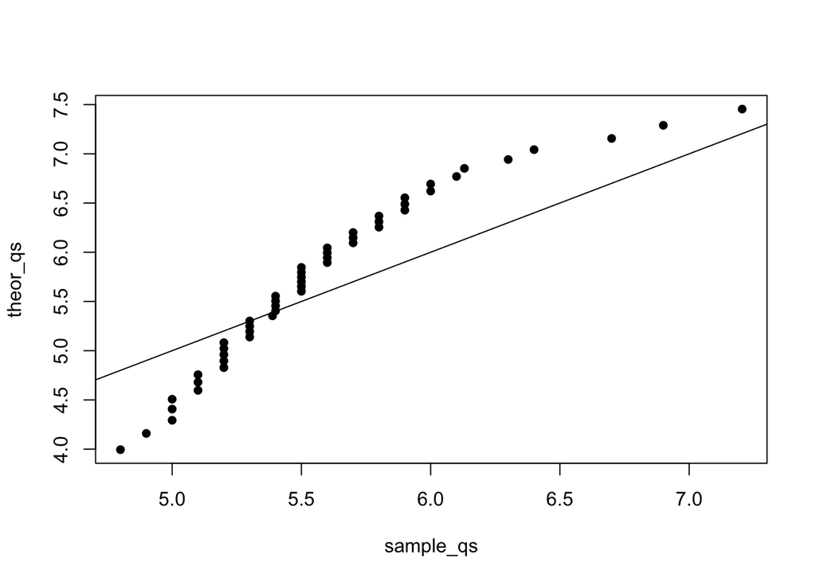

```r
qs <- seq(0.05,0.95,length=50)
sample_qs <- quantile(d1$gh,qs)
theor_qs <- qnorm(qs,mean=coef(param_hat)[1],sd=coef(param_hat)[2])
plot(sample_qs,theor_qs,pch=16)
abline(0,1)
```

Sample max doesn’t fit a straight line with y=x perfectly. We cannot say that the sample quantile fits the theoretical quantile very well.

### 3.2.5 Estimated Median

```r
qnorm(0.5,mean=coef(param_hat)[1],sd=coef(param_hat)[2])
```

```
## [1] 5.7246
```

The estimated Median is 5.7246. We use `qnorm` to select 50% of the observations, 50% of the observations are less than it, and 50% of the observations are greater than it. So this is the median of the sample.

### 3.2.6 Median Samp Dist (hist)

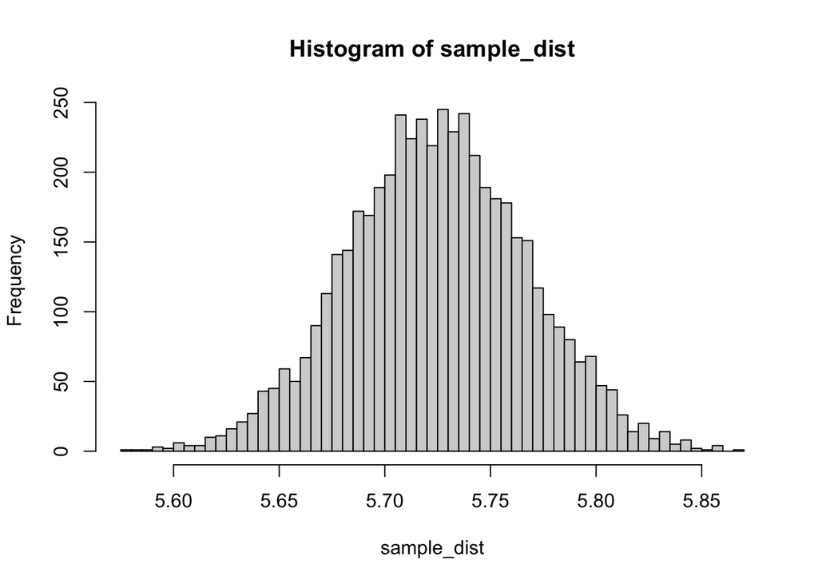

```r
M <- 5000
N <- 1000
out <- rnorm(M*N,mean=coef(param_hat)[1],sd=coef(param_hat)[2]) %>% array( dim=c(M,N))
sample_dist <- apply(out,1,median)
hist(sample_dist, breaks = 100)
```

The figure above is that median Samp Dist (hist). We simulated 5000 experiments, each with 1000 observations, so we take the median of these 5000 experiments. Draw as histogram.

### 3.2.7 Range of middle 95% of Samp Dist

```r
#hist(sample_dist, breaks = 100)
quantile(sample_dist,c(0.05/2, 1 - 0.05/2))
```

```
##     2.5%    97.5%
## 5.642438 5.807453
```

```r
#abline(v = quantile(sample_dist,c(0.05/2, 1 - 0.05/2)), col = "blue", lty = 2)
```

The Range of middle 95% of Samp Dist is from 5.6424381 to 5.8074535. This is the 95% confidence interval. We have 95% confidence that median will be within this range. This has an indicator effect on statistical inference.

## 3.3 Gamma

### 3.3.1 Estimates of parameters

```r
#HT,Gamma, MLE
ll <- function(params, data)  sum(dgamma(data,params[1],params[2],log=TRUE))
#ll(c(2,3),d1$gh)
g <- function(x) {
  out <- x
  for(i in seq_along(x)){
    out[i] <- ll(c(x[i],0.14),d1$gh)
  }
  out
}

h <- function(x) {
  out <- x
  for(i in seq_along(x)){
    out[i] <- ll(c(40,x[i]),d1$gh)
  }
  out
}
```

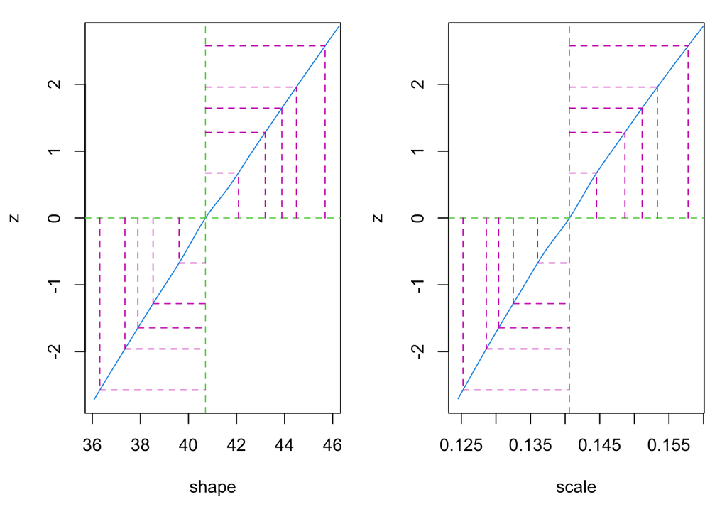

```r
require(stats4)
nLL_gamma <- function(shape, scale){
  fs <- dgamma(
        x = d1$gh
      , shape = shape
      , scale = scale
      , log = TRUE
    )
  -sum(fs)
}
param_hat_gamma <- mle(
    nLL_gamma
  , start = list(shape = 40, scale = 0.14)
  , method = "L-BFGS-B"
  , lower = c(0, 0.01)
)

par(mfrow = c(1,2)); plot(profile(param_hat_gamma), absVal = FALSE)
```

In this chunk, we use function to calculate the MLE when set two parameters that close to real MLE. From the figure, we can see when z=0, the two parameters are what we need.

```r
coef(param_hat_gamma)
```

```
##      shape      scale
## 40.7065036  0.1406358
```

This is the specific value of the two parameters.

### 3.3.2 Overlay estimated pdf onto histogram

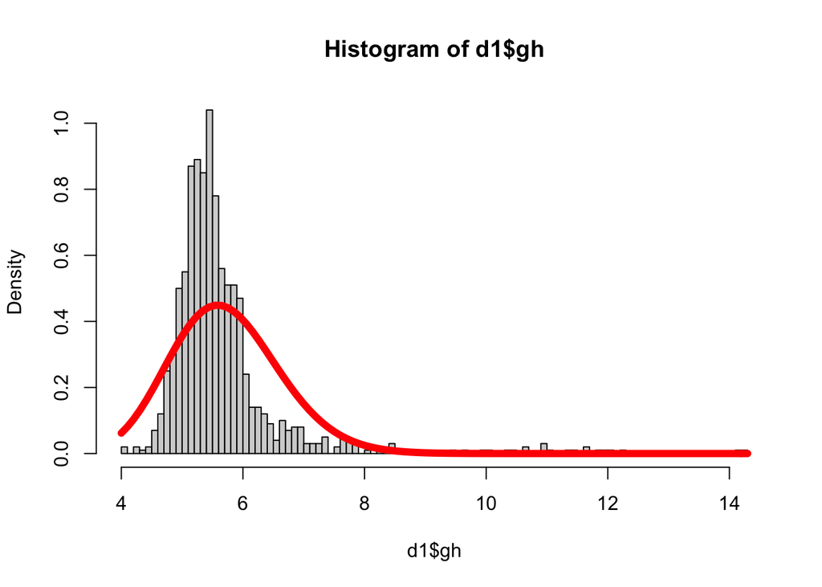

```r
hist(d1$gh,breaks = 100, freq = FALSE)
curve(dgamma(x,shape=coef(param_hat_gamma)[1],scale=coef(param_hat_gamma)[2]),col="red",lwd=6,add=T)
```

The figure above is that overlay estimated pdf onto histogram of the empirical distribution. It can be seen that their distribution is very concentrated in the 4-8 interval.

### 3.3.3 Overlay estimated CDF onto eCDF

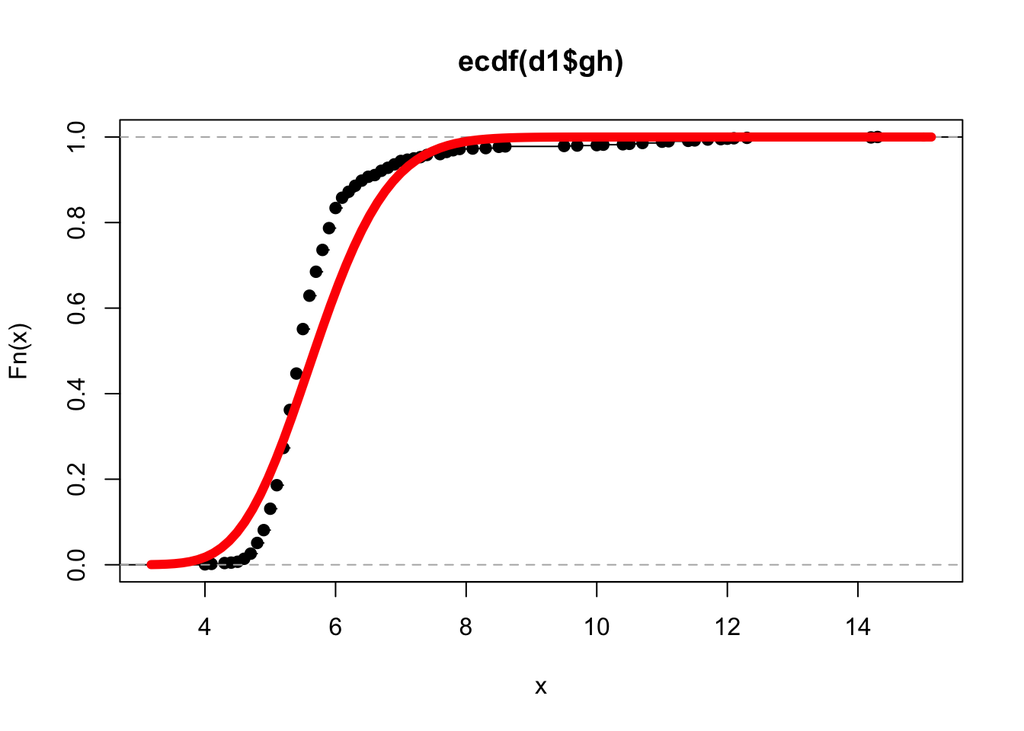

```r
plot(ecdf(d1$gh))
curve(pgamma(x,shape=coef(param_hat_gamma)[1],scale=coef(param_hat_gamma)[2]),col="red",lwd=6,add=T)
```

### 3.3.4 QQ plot (sample vs estimated dist)

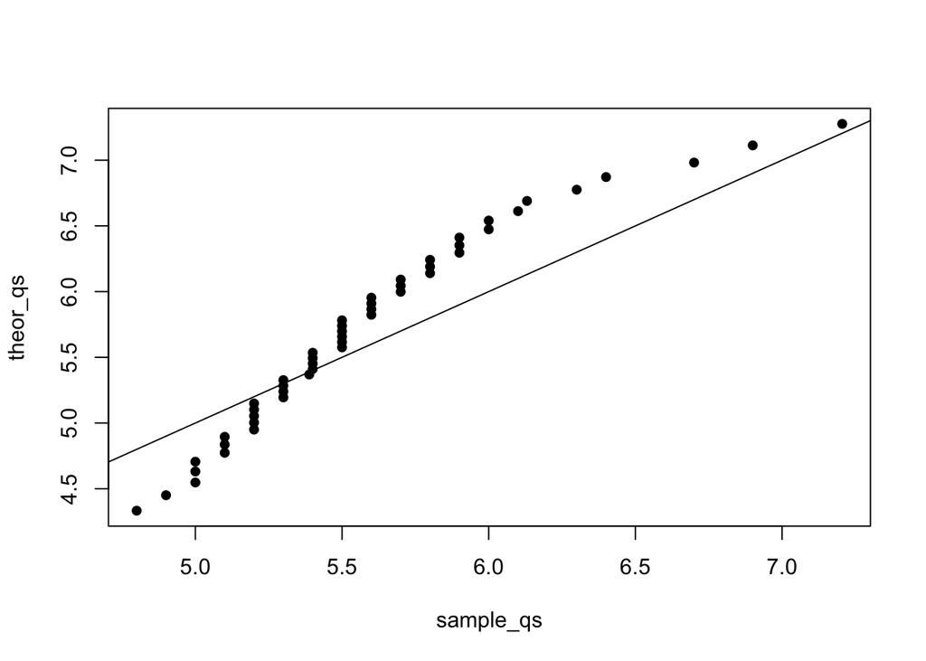

```r
qs <- seq(0.05,0.95,length=50)
sample_qs <- quantile(d1$gh,qs)
theor_qs <- qgamma(qs,shape=coef(param_hat_gamma)[1],scale=coef(param_hat_gamma)[2])
plot(sample_qs,theor_qs,pch=16)
abline(0,1)
```

Sample max doesn’t fit a straight line with y=x perfectly. We cannot say that the sample quantile fits the theoretical quantile very well.

### 3.3.5 Estimated Median

```r
qgamma(0.5,shape=coef(param_hat_gamma)[1],scale=coef(param_hat_gamma)[2])
```

```
## [1] 5.677983
```

The estimated Median is 5.677983. We use `qgamma` to select 50% of the observations, 50% of the observations are less than it, and 50% of the observations are greater than it. So this is the median of the sample.

### 3.3.6 Median Samp Dist (hist)

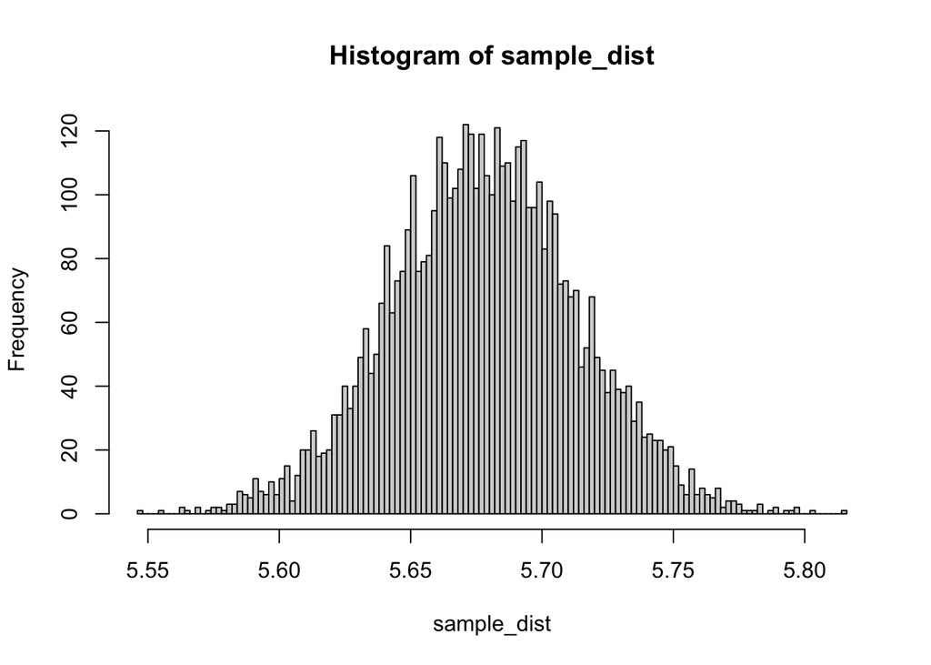

```r
M <- 5000
N <- 1000
out <- rgamma(M*N,shape=coef(param_hat_gamma)[1],scale=coef(param_hat_gamma)[2]) %>% array( dim=c(M,N))
sample_dist <- apply(out,1,median)
hist(sample_dist, breaks = 100)
```

The figure above is that median Samp Dist (hist). We simulated 5000 experiments, each with 1000 observations, so we take the median of these 5000 experiments. Draw as histogram.

### 3.3.7 Range of middle 95% of Samp Dist

```r
quantile(sample_dist,c(0.05/2, 1 - 0.05/2))
```

```
##     2.5%    97.5%
## 5.608274 5.748126
```

The Range of middle 95% of Samp Dist is from 5.608274 to 5.748126. This is the 95% confidence interval. We have 95% confidence that median will be within this range. This has an indicator effect on statistical inference.

## 3.4 Weibull

### 3.4.1 Estimates of parameters

```r
#HT,Gamma, MLE
ll <- function(params, data)  sum(dweibull(data,params[1],params[2],log=TRUE))
#ll(c(2,3),d1$gh)
g <- function(x) {
  out <- x
  for(i in seq_along(x)){
    out[i] <- ll(c(x[i],6.2),d1$gh)
  }
  out
}

h <- function(x) {
  out <- x
  for(i in seq_along(x)){
    out[i] <- ll(c(4.1,x[i]),d1$gh)
  }
  out
}
```

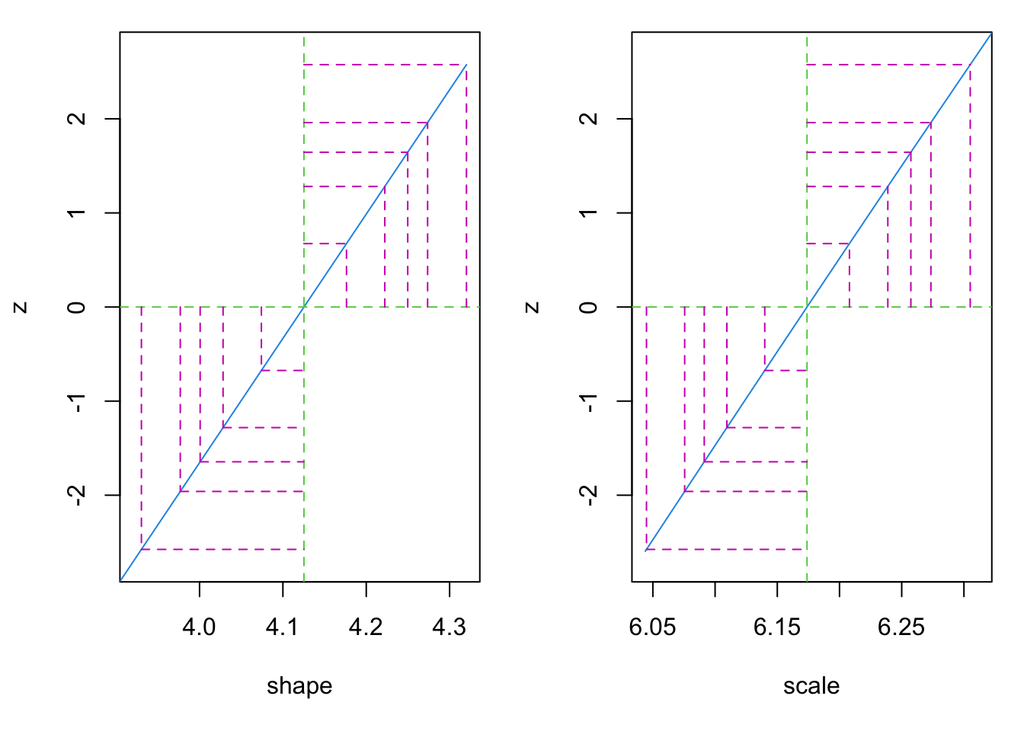

```r
require(stats4)
nLL_weibull <- function(shape, scale){
  fs <- dweibull(
        x = d1$gh
      , shape = shape
      , scale = scale
      , log = TRUE
    )
  -sum(fs)
}
param_hat_weibull <- mle(
    nLL_weibull
  , start = list(shape = 4.1, scale = 6.2)
  , method = "L-BFGS-B"
  , lower = c(0, 0.01)
)

par(mfrow = c(1,2)); plot(profile(param_hat_weibull), absVal = FALSE)
```

In this chunk, we use function to calculate the MLE when set two parameters that close to real MLE. From the figure, we can see when z=0, the two parameters are what we need.

```r
coef(param_hat_weibull)
```

```
##    shape    scale
## 4.125254 6.173884
```

This is the specific value of the two parameters.

### 3.4.2 Overlay estimated pdf onto histogram

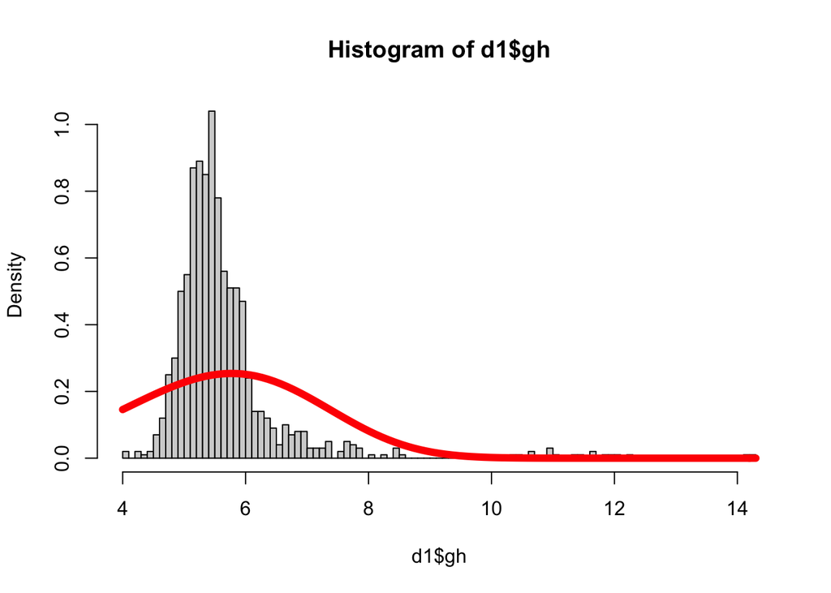

```r
hist(d1$gh,breaks = 100, freq = FALSE)
curve(dweibull(x,shape=coef(param_hat_weibull)[1],scale=coef(param_hat_weibull)[2]),col="red",lwd=6,add=T)
```

The figure above is that overlay estimated pdf onto histogram of the empirical distribution. It can be seen that their distribution is very concentrated in the 4-8 interval.

### 3.4.3 Overlay estimated CDF onto eCDF

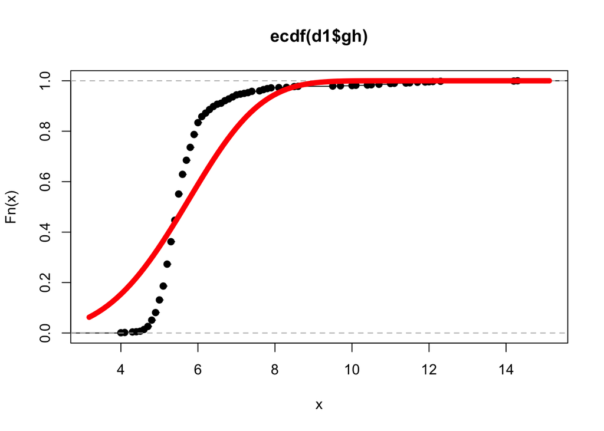

```r
plot(ecdf(d1$gh))
curve(pweibull(x,shape=coef(param_hat_weibull)[1],scale=coef(param_hat_weibull)[2]),col="red",lwd=6,add=T)
```

### 3.4.4 QQ plot (sample vs estimated dist)

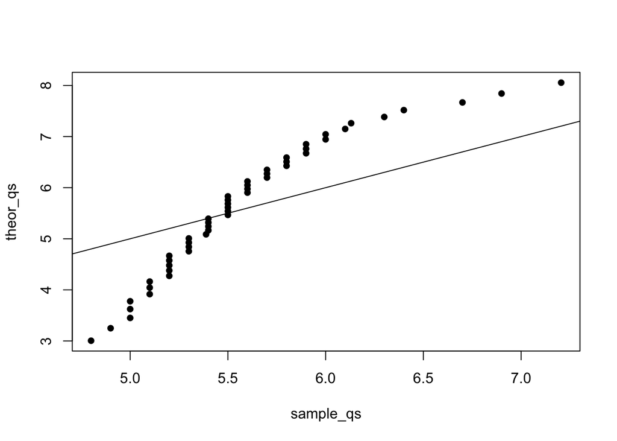

```r
qs <- seq(0.05,0.95,length=50)
sample_qs <- quantile(d1$gh,qs)
theor_qs <- qweibull(qs,shape=coef(param_hat_weibull)[1],scale=coef(param_hat_weibull)[2])
plot(sample_qs,theor_qs,pch=16)
abline(0,1)
```

Sample max doesn’t fit a straight line with y=x perfectly. We cannot say that the sample quantile fits the theoretical quantile very well.

### 3.4.5 Estimated Median

```r
qweibull(0.5,shape=coef(param_hat_weibull)[1],scale=coef(param_hat_weibull)[2])
```

```
## [1] 5.64902
```

The estimated Median is 5.6490199. We use `qweibull` to select 50% of the observations, 50% of the observations are less than it, and 50% of the observations are greater than it. So this is the median of the sample.

### 3.4.6 Median Samp Dist (hist)

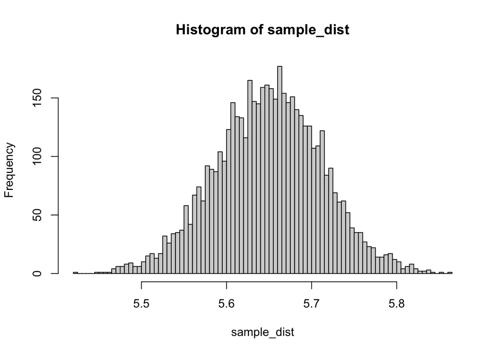

```r
M <- 5000
N <- 1000
out <- rweibull(M*N,shape=coef(param_hat_weibull)[1],scale=coef(param_hat_weibull)[2]) %>% array( dim=c(M,N))
sample_dist <- apply(out,1,median)
hist(sample_dist, breaks = 100)
```

The figure above is that median Samp Dist (hist). We simulated 5000 experiments, each with 1000 observations, so we take the median of these 5000 experiments. Draw as histogram.

### 3.4.7 Range of middle 95% of Samp Dist

```r
quantile(sample_dist,c(0.05/2, 1 - 0.05/2))
```

```
##     2.5%    97.5%
## 5.525778 5.772906
```

The Range of middle 95% of Samp Dist is from 5.5257775 to 5.7729055. This is the 95% confidence interval. We have 95% confidence that median will be within this range. This has an indicator effect on statistical inference.

# 4 Conclusion

In this part, we use MLE to model Glycohemoglobin of adult females and we use three different distributions. The content above answers questions in Background part.